# Description of data from DisGeNET

# Introduction

[DisGeNET](https://www.disgenet.org/) is a discovery platform containing one of the largest publicly available collections of genes and variants associated to human diseases (Piñero et al., 2019; Piñero et al., 2016; Piñero et al., 2015). DisGeNET integrates data from expert curated repositories, GWAS catalogues, animal models and the scientific literature. DisGeNET data are homogeneously annotated with controlled vocabularies and community-driven ontologies. Additionally, several original metrics are provided to assist the prioritization of genotype–phenotype relationships.

The current version of DisGeNET (v6.0) contains 628,685 gene-disease associations (GDAs), between 17,549 genes and 24,166 diseases, disorders, traits, and clinical or abnormal human phenotypes, and 210,498 variant-disease associations (VDAs), between 117,337 variants and 10,358 diseases, traits, and phenotypes.

Here we study the dataset **“Curated gene-disease associations”**. The file contains Gene-Disease associations from UniProt, CGI, ClinGen, Genomics England Panel App, PsyGeNET, Orphanet, the HPO, and CTD (human data).

**The columns in the files are**:

- geneId -> NCBI Entrez Gene Identifier
- geneSymbol -> Official Gene Symbol
- DSI -> The Disease Specificity Index for the gene
- DPI -> The Disease Pleiotropy Index for the gene
- diseaseId -> UMLS concept unique identifier
- diseaseName -> Name of the disease
- diseaseType -> The DisGeNET disease type: disease, phenotype and group
- diseaseClass -> The MeSH disease class(es)
- diseaseSemanticType -> The UMLS Semantic Type(s) of the disease
- score -> DisGENET score for the Gene-Disease association
- EI -> The Evidence Index for the Gene-Disease association
- YearInitial -> First time that the Gene-Disease association was reported
- YearFinal -> Last time that the Gene-Disease association was reported
- NofPmids -> Total number of publications reporting the Gene-Disease association
- NofSnps -> Total number of SNPs associated to the Gene-Disease association
- source -> Original source reporting the Gene-Disease association

# Loading data

We first read the gzipped file.

```r
# Loading th gz file (we keep the file as a zipped file to save space)
zz <- gzfile('curated_gene_disease_associations.tsv.gz','rt')
# read the unzipped file into a dataframe
df <- read.delim(zz)
close(zz)
```

We show the beginning of the file to check its content.

```r
head(df)
```

|  | geneId | geneSymbol | DSI | DPI | diseaseId | diseaseName | diseaseType | diseaseClass | diseaseSemanticType | score | EI | YearInitial | YearFinal | NofPmids | NofSnps | source |
| --- | --- | --- | --- | --- | --- | --- | --- | --- | --- | --- | --- | --- | --- | --- | --- | --- |
| 1 | 1 | A1BG | 0.857 | 0.172 | C0019209 | Hepatomegaly | phenotype | C06;C23 | Finding | 0.3 | NA | 2017 | 2017 | 1 | 0 | CTD_human |
| 2 | 1 | A1BG | 0.857 | 0.172 | C0036341 | Schizophrenia | disease | F03 | Mental or Behavioral Dysfunction | 0.3 | NA | 2015 | 2015 | 1 | 0 | CTD_human |
| 3 | 2 | A2M | 0.564 | 0.724 | C0002395 | Alzheimer's Disease | disease | C10;F03 | Disease or Syndrome | 0.4 | 0.8484848 | 1998 | 2016 | 3 | 0 | CTD_human |
| 4 | 2 | A2M | 0.564 | 0.724 | C0007102 | Malignant tumor of colon | disease | C04;C06 | Neoplastic Process | 0.3 | NA | 2004 | 2004 | 1 | 0 | CTD_human |
| 5 | 2 | A2M | 0.564 | 0.724 | C0009375 | Colonic Neoplasms | group | C04;C06 | Neoplastic Process | 0.3 | NA | 2004 | 2004 | 1 | 0 | CTD_human |
| 6 | 2 | A2M | 0.564 | 0.724 | C0011265 | Presenile dementia | disease | C10;F03 | Mental or Behavioral Dysfunction | 0.3 | NA | 1998 | 2004 | 3 | 0 | CTD_human |

We can also look at **summary statistics** of the file

```r
summary(df)
```

```
     geneId            geneSymbol         DSI              DPI
 Min.   :        1   TNF    :  343   Min.   :0.2510   Min.   :0.0340
 1st Qu.:     2638   SOD2   :  290   1st Qu.:0.4790   1st Qu.:0.4140
 Median :     5428   IL6    :  271   Median :0.5720   Median :0.6210
 Mean   :   621403   PTGS2  :  243   Mean   :0.5773   Mean   :0.5693
 3rd Qu.:    10280   POMC   :  238   3rd Qu.:0.6630   3rd Qu.:0.7590
 Max.   :109580095   IL1B   :  236   Max.   :1.0000   Max.   :0.9660
                     (Other):80125   NA's   :126      NA's   :148
    diseaseId                             diseaseName       diseaseType
 C3714756: 2037   Intellectual Disability       : 2037   disease  :58187
 C0006142: 1025   Malignant neoplasm of breast  : 1025   group    :13513
 C0036341: 1022   Schizophrenia                 : 1022   phenotype:10046
 C0023893:  770   Liver Cirrhosis, Experimental :  770
 C1527249:  676   Colorectal Cancer             :  676
 C0033578:  601   Malignant neoplasm of prostate:  601
 (Other) :75615   (Other)                       :75615
  diseaseClass                         diseaseSemanticType     score
        : 6303   Disease or Syndrome             :34017    Min.   :0.0100
 C04    : 6007   Neoplastic Process              :21132    1st Qu.:0.3000
 C10;C23: 5036   Mental or Behavioral Dysfunction:10468    Median :0.3000
 F03    : 4028   Pathologic Function             : 3114    Mean   :0.3457
 C04;C06: 3831   Congenital Abnormality          : 3061    3rd Qu.:0.3200
 C04;C17: 2719   Sign or Symptom                 : 3012    Max.   :1.0000
 (Other):53822   (Other)                         : 6942
       EI         YearInitial     YearFinal       NofPmids
 Min.   :0.00    Min.   :1916   Min.   :1952   Min.   :  0.000
 1st Qu.:1.00    1st Qu.:2003   1st Qu.:2007   1st Qu.:  1.000
 Median :1.00    Median :2008   Median :2011   Median :  1.000
 Mean   :0.96    Mean   :2006   Mean   :2011   Mean   :  1.378
 3rd Qu.:1.00    3rd Qu.:2012   3rd Qu.:2015   3rd Qu.:  1.000
 Max.   :1.00    Max.   :2018   Max.   :2018   Max.   :124.000
 NA's   :58884   NA's   :8623   NA's   :8623
    NofSnps                                 source
 Min.   :   0.0000   CTD_human                 :56973
 1st Qu.:   0.0000   GENOMICS_ENGLAND          : 7410
 Median :   0.0000   PSYGENET                  : 3531
 Mean   :   0.9828   ORPHANET                  : 3252
 3rd Qu.:   0.0000   UNIPROT                   : 2832
 Max.   :2343.0000   CTD_human;ORPHANET;UNIPROT: 1785
                     (Other)                   : 5963
```

# Temporal insights

There are two timestamps in the dataset:

- YearInitial -> First time that the Gene-Disease association was reported
- YearFinal -> Last time that the Gene-Disease association was reported

From these, we can compute things like:

- Growth of number of discoveries in time.
- How certain genes have been “forgotten”

## Growth process

First it is always good to get an idea of **distributions**. A distribution corresponds to a count of the number (or probability, if normalised) of elements per bin.

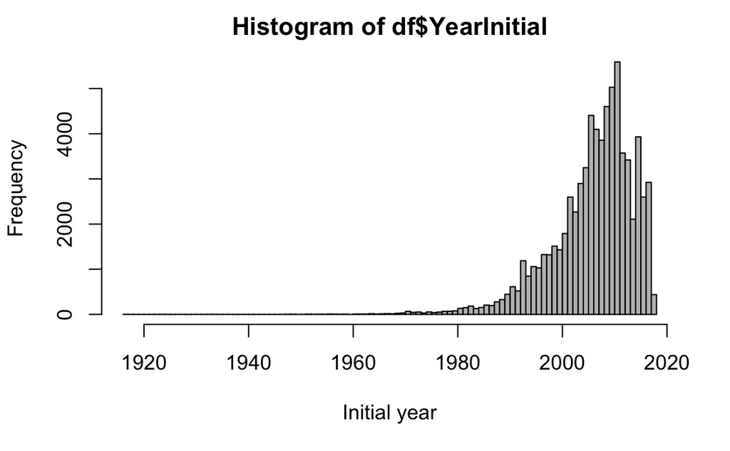

```r
hist(df$YearInitial, col='gray', xlab='Initial year', breaks = 100)
```

What can be observed? There as been a surge in discoveries since the 1980s (beginning of molecular/cellular biology), a rapid increase with arrival of high throughput technics late 1990s, and a more recent decay (there is only a finite amount of possible associations!).

To quantify better this rise-and-fall curve, one can look at the cumulative function! It will show us the cumulative amount of associations found through time. In particular, it will show us if there was a change of rate of increase / decrease through time.

We first compute the number of observations per year

```r
tb <- table(df$YearInitial)
head(tb)
```

```
1916 1924 1933 1948 1949 1951
   1    1    1    2    3    1
```

And then we can look at the cumulative sum:

```r
x <- as.numeric(names(tb))
y <- cumsum(as.numeric(tb))
# another way os to do a empirical cumulative distribution, which is normalised to 1
# y <- ecdf(df$YearInitial)(x)
```

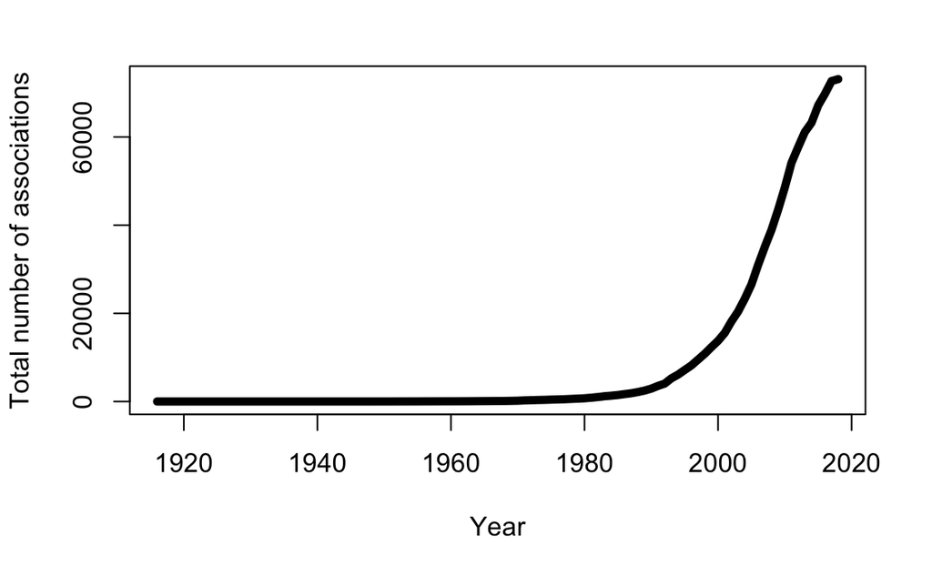

```r
plot(x,y, pch=19, type='l', xlab='Year', ylab='Total number of associations', lwd=5)
```

To better understand if the rates of increase are changing, we need to use a log scale.

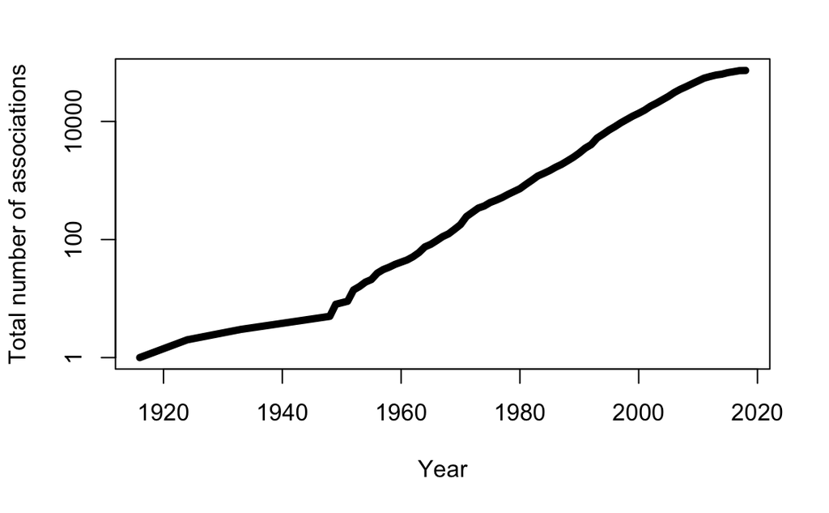

```r
plot(x,y, log='y',
     pch=19, type='l', xlab='Year', ylab='Total number of associations', lwd=5)
```

The linearity of the curve tells us a story! The discovery rate of novel associations follows an exponental growth $y \sim e^{at}$. The rate $a$ gives us the rate of growth. For example to get the doubling rate (time to have twice the number of known associations) we compute

$$\frac{2y}{y} = e^{a(t_2-t_1)}$$

$$t_2-t_1 =1/a * \log(2)$$

Let us fit the data with a linear fit! The function *lm* generates a linear regression model:

$$y \sim x \Leftrightarrow y=ax+b$$

```r
# we are interested in the log here!
logy <- log(y)/log(2)
# we don't want to fit before 1945
inds <- which(x>1945)
# the lm function can be understood by looking at the manual through ?lm
fit <- lm(logy[inds]~x[inds])
```

Once the fit is created we can observe the statistics of the quality of fit (see ?summary.lm for help). Here, we are interested in

```r
summary(fit)
```

```
Call:
lm(formula = logy[inds] ~ x[inds])

Residuals:
     Min       1Q   Median       3Q      Max
-0.97530 -0.06874  0.04262  0.19067  0.33080

Coefficients:
             Estimate Std. Error t value Pr(>|t|)
(Intercept) -388.7313     3.1743  -122.5   <2e-16 ***
x[inds]        0.2011     0.0016   125.7   <2e-16 ***
---
Signif. codes:  0 ‘***’ 0.001 ‘**’ 0.01 ‘*’ 0.05 ‘.’ 0.1 ‘ ’ 1

Residual standard error: 0.2685 on 67 degrees of freedom
Multiple R-squared:  0.9958,    Adjusted R-squared:  0.9957
F-statistic: 1.58e+04 on 1 and 67 DF,  p-value: < 2.2e-16
```

Let us represent things a bit better. We can plot the fit on top of the other curve!

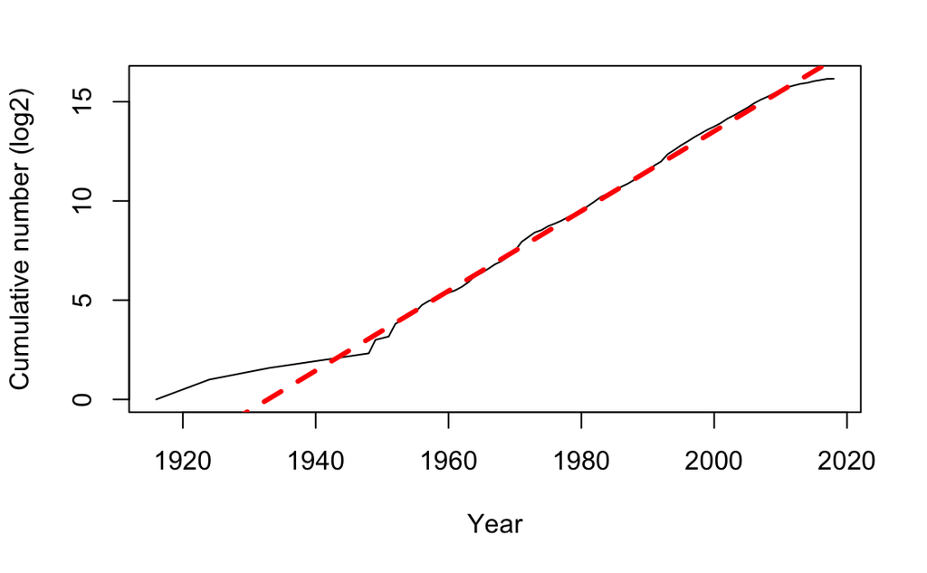

```r
plot(x,logy, type='l', cex=0.2, xlab='Year',ylab='Cumulative number (log2)')
abline(fit, lty=2, col='red', lwd=3)
```

The trend is observed to be a very good fit! So what does it give us in terms of doubling rate $t_2-t_1 =\frac{\log(2)}{a}$?

```r
a <- fit$coefficients[2]
# the fit already incliudes the term log(2) in our case
doubling_rate <- 1 / a
print(paste('The total number of known associations doubles every',
            signif(doubling_rate,2),
            'years!'))
```

```
[1] "The total number of known associations doubles every 5 years!"
```

## Evolution of quantities

Now we are interested in the “Final” year an association has been observed. This gives some insights about which associations have been forgotten. Let us see first look at how this final year depends on the initial year.

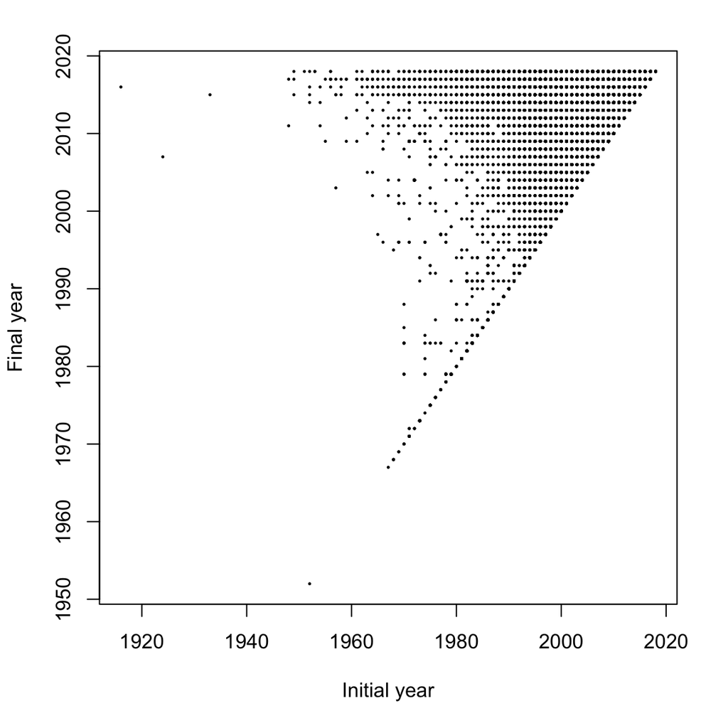

```r
#fig.asp=1 makes a square, easier to visualise y=x
plot(df$YearInitial, df$YearFinal,
     pch=19, # nicer looking
     cex=0.2, # many points so we reduce the size
     xlab='Initial year',
     ylab='Final year'
     )
```

Elements on the diagonal have only been observed once. The more “up” we are, the longer the observation has been observed. We want to understand the relative time an association has been observed. For this we compute a normalised duration:

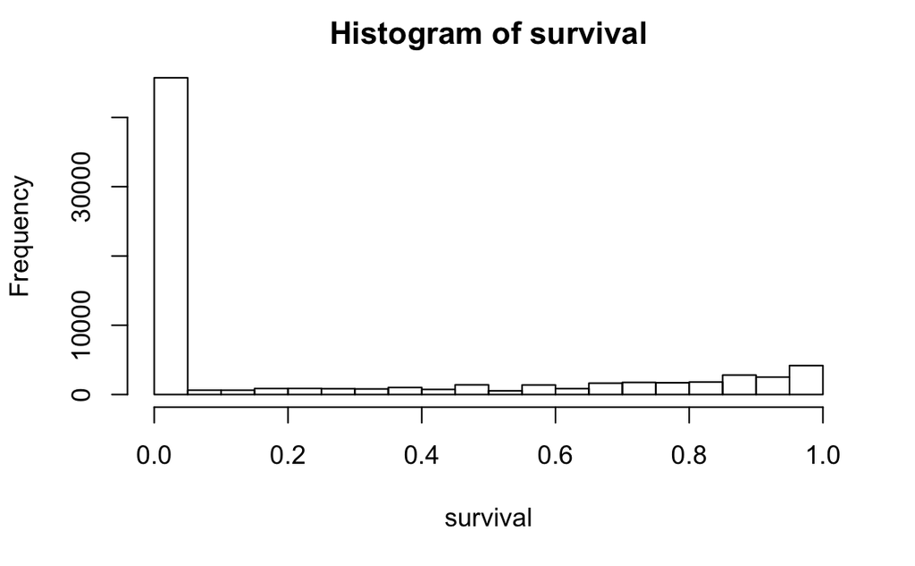

```r
dt <- df$YearFinal - df$YearInitial
dt_max <- max(df$YearInitial, df$YearFinal, na.rm=T) - df$YearInitial
survival <- dt / dt_max
hist(survival)
```

We see a lot of associations are at 0 (only observed once). We can filter them out to see better the rest of the distribution

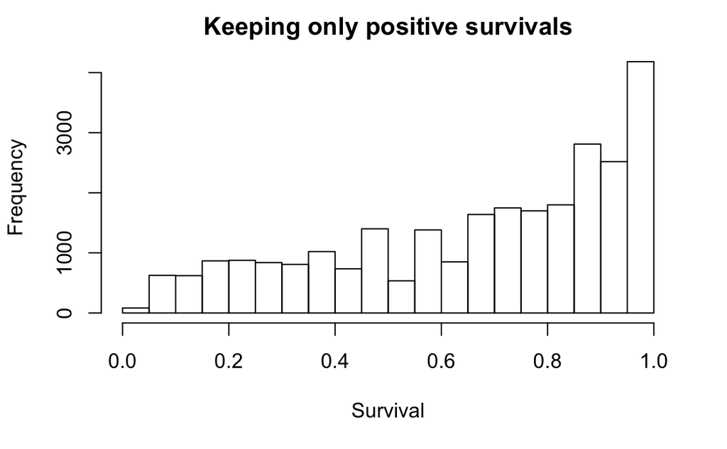

```r
inds <- which(survival>0)
hist(survival[inds], xlab='Survival', main='Keeping only positive survivals')
```

Now we wonder what are the trends for survival? Did it change in time? Are the first associations found more “interesting” (i.e they have been surviving longer)?

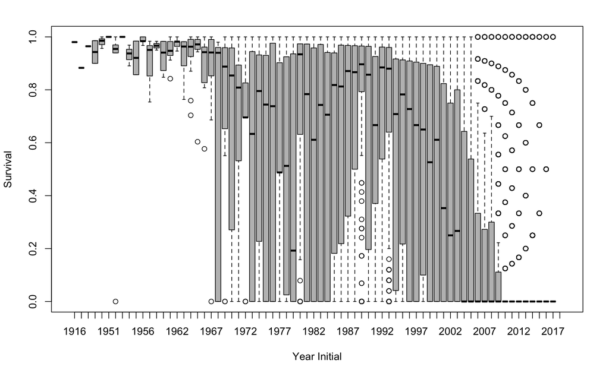

```r
# this creates a list of survivals for each Year Initial
sp <- split(survival, df$YearInitial)
boxplot(sp, xlab='Year Initial', ylab='Survival',col='gray')
```

We can have a simpler way to look at this through mean and standard error:

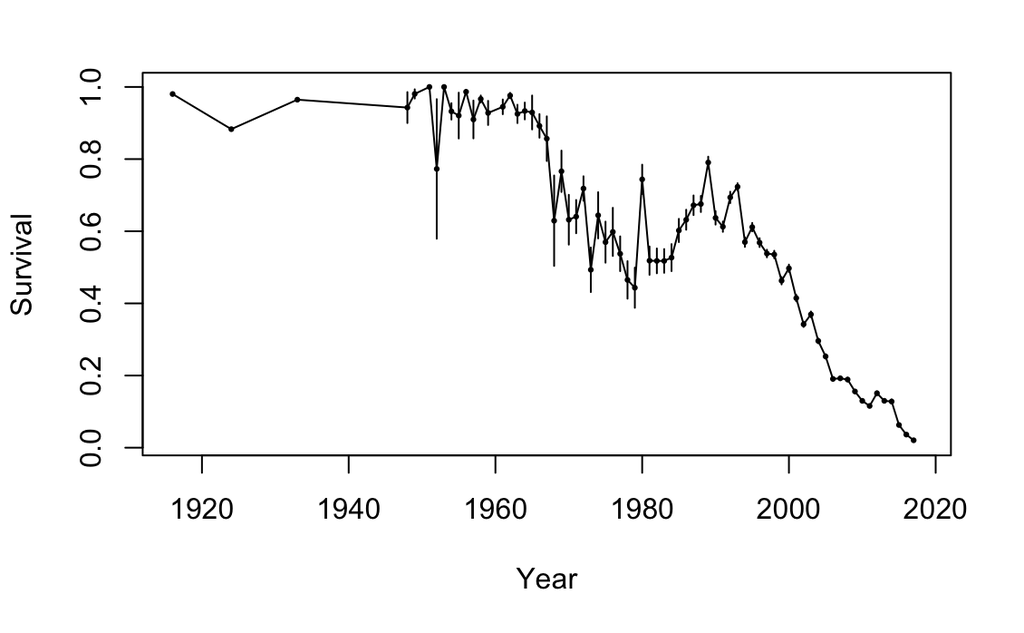

```r
# this library allows to plot error bars
require(gplots)
# we compute the mean and standard error for each element of the list
means <- sapply(sp, mean, na.rm=T)
stderrs <- sapply(sp, function(x) sd(x, na.rm=T) / sqrt(length(x)))
years <- as.numeric(names(means))
# barplot.split(df$YearInitial[inds], survival[inds])
# plot(means, border = NA, ylab='Survival', las =3)
plotCI(years, means, stderrs,
       xlab='Year',
       ylab='Survival',
       gap=0, pch=19, type='o',cex=0.3, sfrac=0)
```

Let us try to distinguish two periods: before 1970 and after. We want to explore simple tests that these periods have different survival distributions.

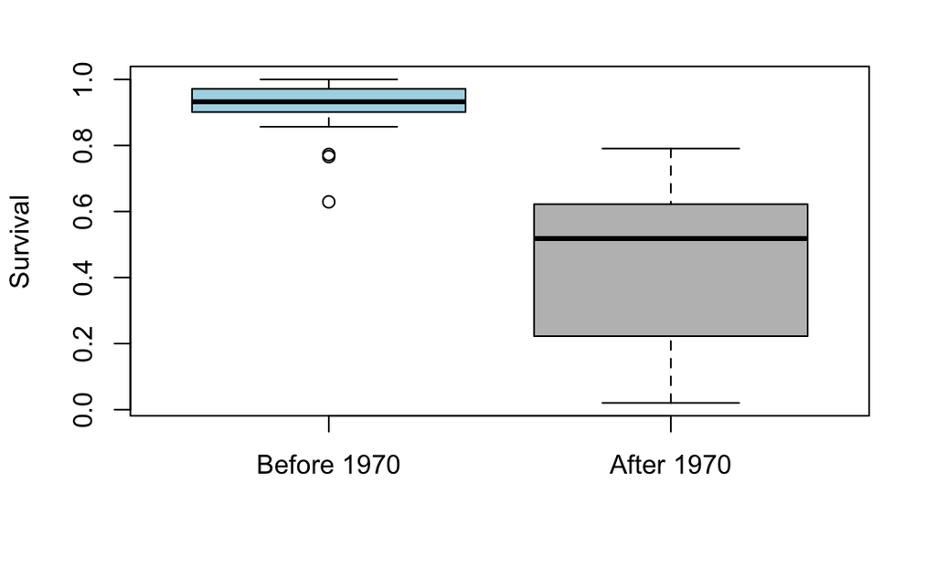

```r
means1 <- means[which(years<1970)]
means2 <- means[which(years>=1970)]
boxplot(list('Before 1970'=means1,
             'After 1970'=means2),
        col=c('lightblue','gray'),
        ylab='Survival')
```

When we have two distributions like this, we want to test that they are different.

To do this we can use a *non-parametric* method. By this we mean that this method looks at the **rank** of quantities, not their absolute values. In this context, we want to show that before 1970 survival is higher than after 1970. We convert survival to a rank (first largest, second largest etc) and we test that “Before 1970” has higher rank.

This can be easily seen using a ROC curve. The ROC curve is used in classification schemes to test that one distribution is separated from another one. The more the ROC curves points towards the top-left corner the better.

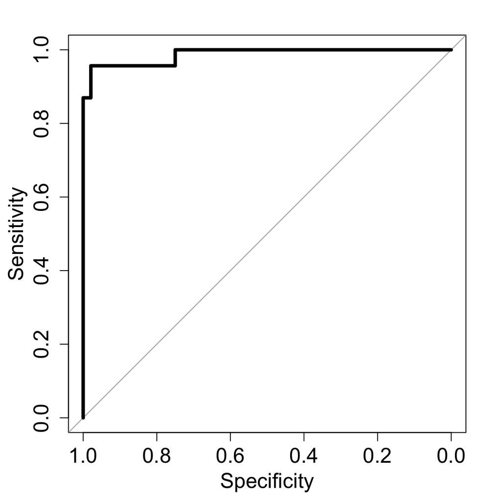

```r
library(pROC)
responses <- c(means1, means2)
labels <- c(rep(1, length(means1)), rep(0, length(means2)))
r <- roc(labels, responses, direction="<", levels = c(0,1))
plot(r, cex.lab=1.5, cex.axis=1.5, lwd=4)
```

Here the ROC curve looks really good. We can quantify this in two ways. First, one can compute the area under the ROC curve (AUC), and if the AUC is above 0.5, this point towards distinct distirbutions.

```r
print(r)
```

```
Call:
roc.default(response = labels, predictor = responses, levels = c(0,     1), direction = "<")

Data: responses in 48 controls (labels 0) < 23 cases (labels 1).
Area under the curve: 0.9873
```

Here an AUC of 0.98 is extremely good. However it is possible to have hjigh values by chance when we have low number of observations. To control for this, we compute a probability to observe such a high value by chance given the number of observations. To do this, we can use the *Mann Whitney U test* also call *wilcoxon test*

```r
wilcox.test(means1, means2, alternative = 'greater')
```

```
cannot compute exact p-value with ties
```

```
    Wilcoxon rank sum test with continuity correction

data:  means1 and means2
W = 1090, p-value = 1.998e-11
alternative hypothesis: true location shift is greater than 0
```

We see that the p-value that AUC is this big is ~2e-11, very significant as expected “by eye”.

# Networks!

Now that we have done some work on the temporal aspect of the distributions, we explore the bipartite network of gene to diseases.

in R the library igraph is used to work with networks.

```r
require(igraph)
```

We first create a simple bipartite network of genes and diseases.

```r
edgelist <- data.frame(df$geneSymbol, df$diseaseName)
G <- graph_from_data_frame(edgelist)
```

```r
G
```

```
IGRAPH dca2730 DN-- 19781 81746 --
+ attr: name (v/c)
+ edges from dca2730 (vertex names):
 [1] A1BG->Hepatomegaly                  A1BG->Schizophrenia
 [3] A2M ->Alzheimer's Disease           A2M ->Malignant tumor of colon
 [5] A2M ->Colonic Neoplasms             A2M ->Presenile dementia
 [7] A2M ->Mental Depression             A2M ->Depressive disorder
 [9] A2M ->Hepatolenticular Degeneration A2M ->Kidney Failure, Acute
[11] A2M ->Liver Cirrhosis               A2M ->Liver Cirrhosis, Experimental
[13] A2M ->Lung diseases                 A2M ->Lung Neoplasms
[15] A2M ->Nephrotic Syndrome            A2M ->Hepatocellular Adenoma
+ ... omitted several edges
```

The first line always starts with IGRAPH, showing you that the object is an igraph graph. Then a seven character code is printed, this the first seven characters of the unique id of the graph. See graph_id for more. Then a four letter long code string is printed. The first letter distinguishes between directed (‘D’) and undirected (‘U’) graphs. The second letter is ‘N’ for named graphs, i.e. graphs with the name vertex attribute set. The third letter is ‘W’ for weighted graphs, i.e. graphs with the weight edge attribute set. The fourth letter is ‘B’ for bipartite graphs, i.e. for graphs with the type vertex attribute set.

## Bipartite graphs

To work with bipartite graphs we use https://rpubs.com/pjmurphy/317838. Igraph can evaluate the network that you have entered for whether it meets the criteria of a two-mode network. Those criteria are that there are (1) two sets of nodes in the network, and (2) there are only ties between node sets and not within them. That is, there are two sets of entities in the network, and the entities from each set are only connected with one another through the other node set. If the network meets the criteria, igraph will identify which nodes belong in each mode.

```r
lapply(bipartite.mapping(G), head)
```

```
$res
[1] TRUE

$type
[1] FALSE FALSE FALSE FALSE FALSE FALSE
```

The “type” argument is what igraph uses to identify the two modes. We can add this into the network fairly easily.

```r
V(G)$type <- bipartite_mapping(G)$type
```

```r
G
```

```
IGRAPH dca2730 DN-B 19781 81746 --
+ attr: name (v/c), type (v/l)
+ edges from dca2730 (vertex names):
 [1] A1BG->Hepatomegaly                  A1BG->Schizophrenia
 [3] A2M ->Alzheimer's Disease           A2M ->Malignant tumor of colon
 [5] A2M ->Colonic Neoplasms             A2M ->Presenile dementia
 [7] A2M ->Mental Depression             A2M ->Depressive disorder
 [9] A2M ->Hepatolenticular Degeneration A2M ->Kidney Failure, Acute
[11] A2M ->Liver Cirrhosis               A2M ->Liver Cirrhosis, Experimental
[13] A2M ->Lung diseases                 A2M ->Lung Neoplasms
[15] A2M ->Nephrotic Syndrome            A2M ->Hepatocellular Adenoma
+ ... omitted several edges
```

See how now we have a “B” signalling that this is a bipartite graph?

Then we can **project** the bipartite network to each of its layers (a bit long). `multiplicity=TRUE` ensures to compute edge weights based on number of shared items in other layer.

```r
Gproj <- bipartite_projection(G, multiplicity = TRUE)
```

```r
Gproj
```

```
$proj1
IGRAPH 279c75c UNW- 9411 4674633 --
+ attr: name (v/c), weight (e/n)
+ edges from 279c75c (vertex names):
 [1] A1BG--AHR      A1BG--ALDH1B1  A1BG--CAMK2A   A1BG--CRYGD
 [5] A1BG--CYBA     A1BG--CYP1A1   A1BG--CYP1A2   A1BG--CYP1B1
 [9] A1BG--ADAM3A   A1BG--DSCAM    A1BG--FGF12    A1BG--HDC
[13] A1BG--IGKC     A1BG--LEPR     A1BG--MYO1B    A1BG--TRIM37
[17] A1BG--PEPD     A1BG--PPARA    A1BG--NR1H2    A1BG--KLF11
[21] A1BG--COPS3    A1BG--ABCC3    A1BG--NR1I2    A1BG--ATG5
[25] A1BG--ADAMTSL2 A1BG--NR1I3    A1BG--NR1H4    A1BG--ADAMTS5
[29] A1BG--AKR7A3   A1BG--MLC1     A1BG--DAPK2    A1BG--SLC29A3
+ ... omitted several edges

$proj2
IGRAPH a2c3e2f UNW- 10370 751068 --
+ attr: name (v/c), weight (e/n)
+ edges from a2c3e2f (vertex names):
 [1] Hepatomegaly--Schizophrenia
 [2] Hepatomegaly--Malignant Neoplasms
 [3] Hepatomegaly--Neoplasms
 [4] Hepatomegaly--Prostatic Neoplasms
 [5] Hepatomegaly--Benign Neoplasm
 [6] Hepatomegaly--Malignant neoplasm of prostate
 [7] Hepatomegaly--Malignant neoplasm of breast
 [8] Hepatomegaly--Hepatitis, Toxic
+ ... omitted several edges
```

## Strength distribution

From edge weights one can compute the weighted degree or “strength”. It corresponds to the sum of the weights of the edges adjacent to a node (or vertex).

```r
s_genes <- strength(Gproj$proj1)
s_diseases <- strength(Gproj$proj2)
```

### Diseases

Let us look at how diseases are wired together!

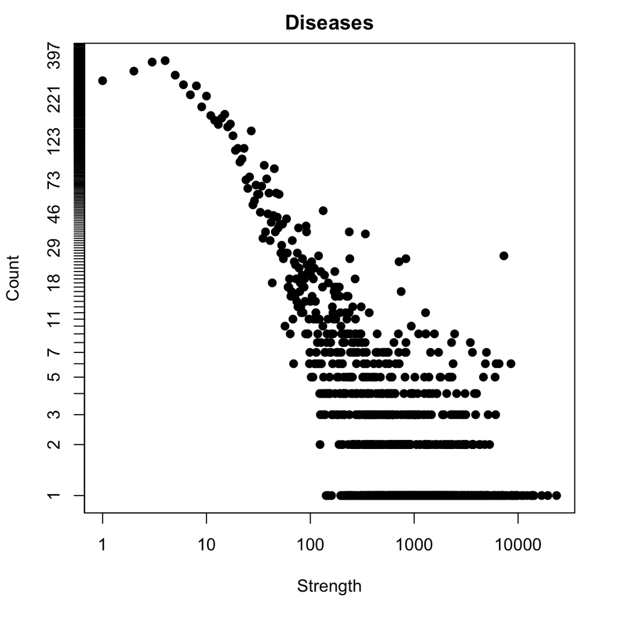

```r
tb <- table(s_diseases)
x <- as.numeric(names(tb))
y <- tb
plot(x,y, log='xy', pch=19, xlab='Strength', ylab='Count', main='Diseases')
```

Let’s bin this a bit better

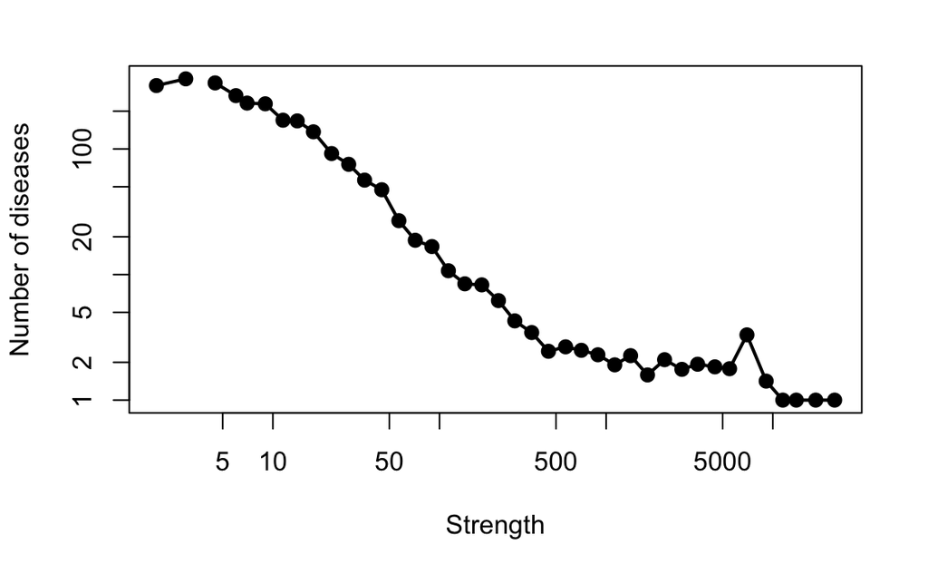

```r
breaks <- 10^seq(0,5,0.1)
cuts <- cut(x, breaks)
x0 <- sapply(split(x, cuts), mean)
y0 <- sapply(split(y, cuts), mean)
plot(x0,y0,log='xy', type='o',lwd=2,pch=19,
     ylab='Number of diseases', xlab='Strength')
```

It looks like we have a scale-free distribution between strengths 3 and 500, and another one above with a different exponent. Let’s test this.

```r
# we are interested in the log of both quantities!
logx <- log10(x0)
logy <- log10(y0)
# first slopt
inds <- which(x0>3 & x0<500)
fit1 <- lm(logy[inds]~logx[inds])
# second slope
inds <- which(x0>500)
fit2 <- lm(logy[inds]~logx[inds])
```

```r
summary(fit1)
```

```
Call:
lm(formula = logy[inds] ~ logx[inds])

Residuals:
      Min        1Q    Median        3Q       Max
-0.146562 -0.059395  0.002227  0.070986  0.122106

Coefficients:
            Estimate Std. Error t value Pr(>|t|)
(Intercept)  3.40193    0.05138   66.21   <2e-16 ***
logx[inds]  -1.11607    0.02918  -38.24   <2e-16 ***
---
Signif. codes:  0 ‘***’ 0.001 ‘**’ 0.01 ‘*’ 0.05 ‘.’ 0.1 ‘ ’ 1

Residual standard error: 0.08084 on 19 degrees of freedom
Multiple R-squared:  0.9872,    Adjusted R-squared:  0.9865
F-statistic:  1462 on 1 and 19 DF,  p-value: < 2.2e-16
```

```r
summary(fit2)
```

```
Call:
lm(formula = logy[inds] ~ logx[inds])

Residuals:
     Min       1Q   Median       3Q      Max
-0.11755 -0.07051 -0.00886  0.03528  0.35070

Coefficients:
            Estimate Std. Error t value Pr(>|t|)
(Intercept)  1.08455    0.19463   5.572 5.33e-05 ***
logx[inds]  -0.23818    0.05428  -4.388 0.000529 ***
---
Signif. codes:  0 ‘***’ 0.001 ‘**’ 0.01 ‘*’ 0.05 ‘.’ 0.1 ‘ ’ 1

Residual standard error: 0.1101 on 15 degrees of freedom
Multiple R-squared:  0.5621,    Adjusted R-squared:  0.5329
F-statistic: 19.26 on 1 and 15 DF,  p-value: 0.0005292
```

Both fits seem to be pretty good, with exponents close to 1 and 0.2. Let’s visualise to see.

```r
plot(logx,logy, type='o', cex=1, pch=19,lwd=2,
     xlab='Strength (log10)',ylab='Number of observations (log10)')
abline(fit1, lty=2, col='red', lwd=3)
```

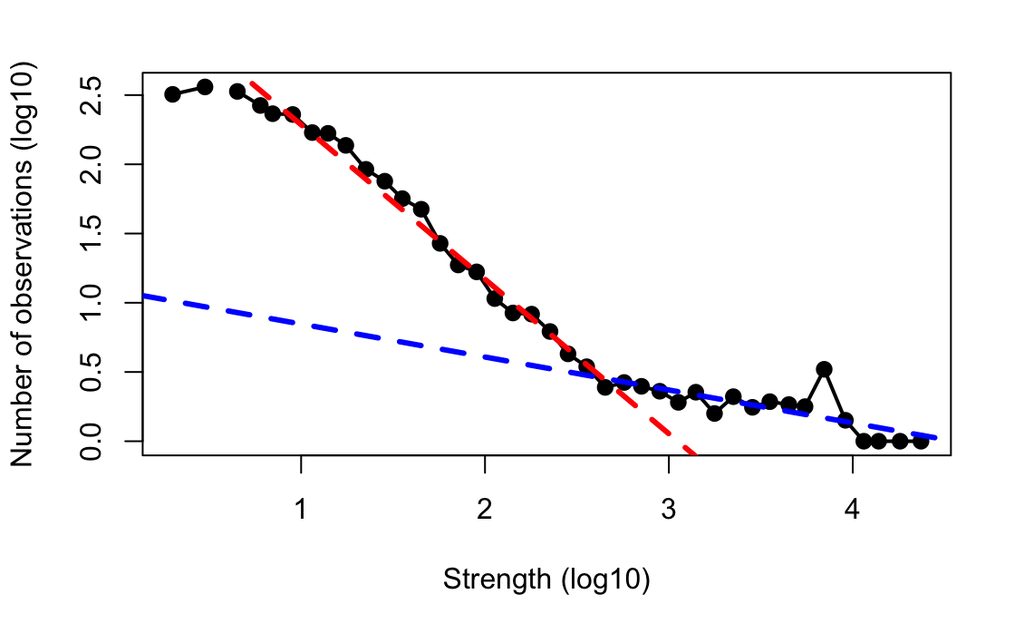

```r
abline(fit2, lty=2, col='blue', lwd=3)
```

Pretty nice, hey? Let’s try for genes!

### Genes

```
1 x value <= 0 omitted from logarithmic plot
```

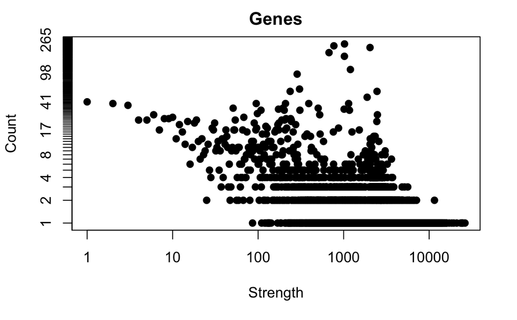

```r
tb <- table(s_genes)
x <- as.numeric(names(tb))
y <- tb
plot(x,y, log='xy', pch=19, xlab='Strength', ylab='Count', main='Genes')
```

Binning

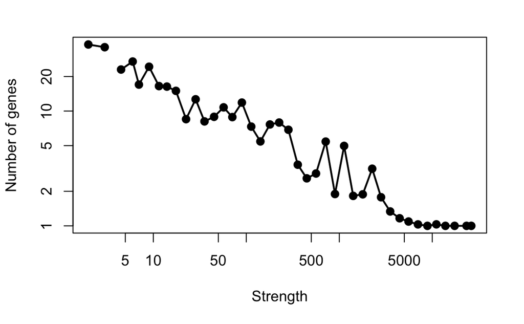

```r
breaks <- 10^seq(0,5,0.1)
cuts <- cut(x, breaks)
y0 <- sapply(split(y, cuts), mean)
x0 <- sapply(split(x, cuts), mean)
plot(x0,y0,log='xy', type='o',lwd=2,pch=19,
     ylab='Number of genes', xlab='Strength')
```

It looks like we have a scale-free distribution almost all the way!

```r
# we are interested in the log of both quantities!
logx <- log10(x0)
logy <- log10(y0)
inds <- which(x0<5000)
fit <- lm(logy[inds]~logx[inds])
```

```r
summary(fit)
```

```
Call:
lm(formula = logy[inds] ~ logx[inds])

Residuals:
     Min       1Q   Median       3Q      Max
-0.20297 -0.09889 -0.00457  0.06682  0.26720

Coefficients:
            Estimate Std. Error t value Pr(>|t|)
(Intercept)  1.69185    0.05250   32.23   <2e-16 ***
logx[inds]  -0.41374    0.02322  -17.82   <2e-16 ***
---
Signif. codes:  0 ‘***’ 0.001 ‘**’ 0.01 ‘*’ 0.05 ‘.’ 0.1 ‘ ’ 1

Residual standard error: 0.1284 on 31 degrees of freedom
Multiple R-squared:  0.911, Adjusted R-squared:  0.9082
F-statistic: 317.4 on 1 and 31 DF,  p-value: < 2.2e-16
```

Fit seems to be pretty good, with exponents close to 0.4. Let’s visualise to see.

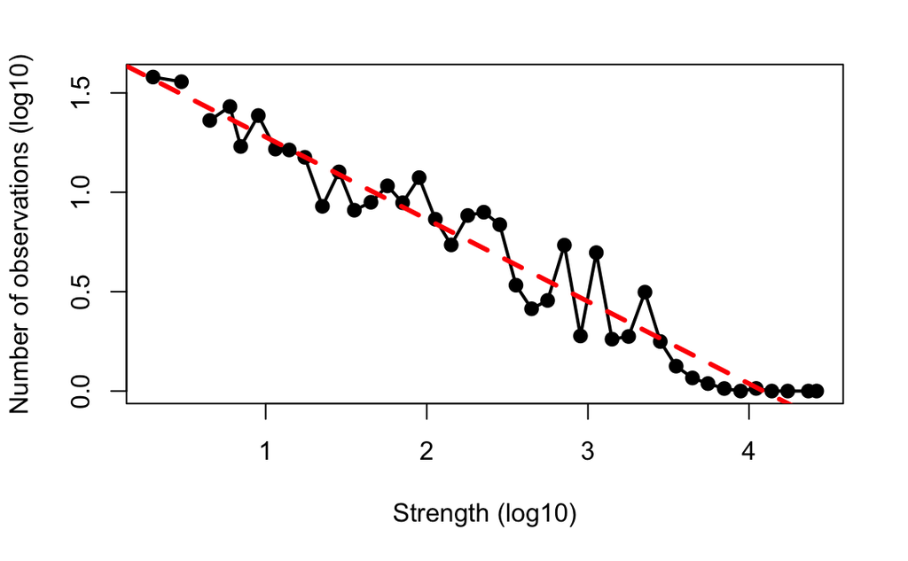

```r
plot(logx,logy, type='o', cex=1, pch=19,lwd=2,
     xlab='Strength (log10)',ylab='Number of observations (log10)')
abline(fit, lty=2, col='red', lwd=3)
```

Great! Now the question: what are all these hubs??

## Hubs

### Genes

```r
inds_genes <- which(s_genes>1e4)
names(s_genes[inds_genes])
```

```
 [1] "ACHE"   "AGT"    "AHR"    "AKT1"   "APC"    "ATP7B"  "CCND1"  "BCL2"
 [9] "BDNF"   "BRAF"   "BRCA2"  "CAT"    "CDH1"   "CDKN2A" "CNR1"   "CSF3"
[17] "CTNNB1" "ACE"    "DNMT1"  "DPYD"   "DRD2"   "EGFR"   "ENO1"   "ESR1"
[25] "ESR2"   "FGFR1"  "FGFR2"  "FOS"    "GSTM1"  "GSTP1"  "HMOX1"  "HRAS"
[33] "IFNA2"  "IFNG"   "IGF1"   "IL1B"   "IL6"    "CXCL8"  "KRAS"   "LEP"
[41] "MET"    "MMP9"   "MTHFR"  "NOS2"   "NOS3"   "PDYN"   "ABCB1"  "PIK3CA"
[49] "POMC"   "PTEN"   "PTGS2"  "CCL2"   "SLC2A1" "SOD2"   "STAT3"  "TERT"
[57] "TGFB1"  "TNF"    "TP53"   "VEGFA"
```

These are a lot related to the immune system, signalling pathways etc.

Are these simply the ones predicted by number of diseases?

```r
# number of diseases per gene
tb <- table(df$geneSymbol)
head(sort(tb, decreasing = T), 60)
```

```
   TNF   SOD2    IL6  PTGS2   POMC   IL1B   TP53  MTHFR   NOS2   PTEN
   343    290    271    243    238    236    217    195    178    177
 VEGFA  IFNA2   CSF3  TGFB1   IFNG    CAT   KRAS   SOD1    INS  HMOX1
   176    172    169    168    167    166    160    156    150    140
   AGT   CCL2   PLAT   BCL2   DRD2   MMP9   BCHE   NOS3   BDNF   EGFR
   138    138    138    137    136    135    134    127    126    124
CTNNB1  STAT3   APOE   HRAS    ALB    NGF   CNR1   AKT1 CDKN2A   ESR1
   123    122    121    119    118    118    116    115    113    113
  BRAF   IGF1    OXT   PON1   BAP1    LEP    NPY    CRH   EDN1  OPRM1
   110    110    110    110    109    109    109    108    108    108
  PLAU    FOS PIK3CA    ACE  CXCL8   PDYN   CSF2    APC  GSTP1  PPARG
   106    105    105    104    104    104    103    102    102    102
```

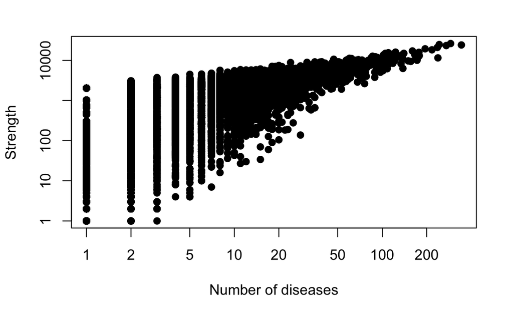

```r
# matching the two tables together
inds_match <- match(names(tb), names(s_genes))
# plotting one vs the other
plot(as.numeric(tb), s_genes[inds_match], log='xy', pch=19,
     ylab='Strength', xlab='Number of diseases')
```

One can compute a correlation odf the two datasets. We use Spearman correlation, a rank correlation that removes the parametrisation.

```r
cor.test(as.numeric(tb), s_genes[inds_match], method='s')
```

```
Cannot compute exact p-value with ties
```

```
    Spearman's rank correlation rho

data:  as.numeric(tb) and s_genes[inds_match]
S = 4.9675e+10, p-value < 2.2e-16
alternative hypothesis: true rho is not equal to 0
sample estimates:
      rho
0.6424133
```

There is a strong correlation, but not absolute. Indeed, some hubs have a very low number of diseases associations.

In any case, to do this projection in a clean way one would need to use a probabilistic method to prune relevant edges.

### Diseases

Same story for diseases

```r
inds_diseases <- which(s_diseases>1e4)
names(s_diseases[inds_diseases])
```

```
 [1] "Schizophrenia"                  "Depressive disorder"
 [3] "Liver Cirrhosis, Experimental"  "Prostatic Neoplasms"
 [5] "Malignant neoplasm of prostate" "Malignant neoplasm of breast"
 [7] "Breast Carcinoma"               "Mammary Neoplasms, Human"
 [9] "Mammary Neoplasms"              "Intellectual Disability"
[11] "Bipolar Disorder"
```

```r
# number of diseases per gene
tb <- table(df$diseaseName)
head(sort(tb, decreasing = T), 10)
```

```
       Intellectual Disability   Malignant neoplasm of breast
                          2037                           1025
                 Schizophrenia  Liver Cirrhosis, Experimental
                          1022                            770
             Colorectal Cancer Malignant neoplasm of prostate
                           676                            601
           Prostatic Neoplasms               Bipolar Disorder
                           601                            505
              Breast Carcinoma              Mammary Neoplasms
                           487                            476
```

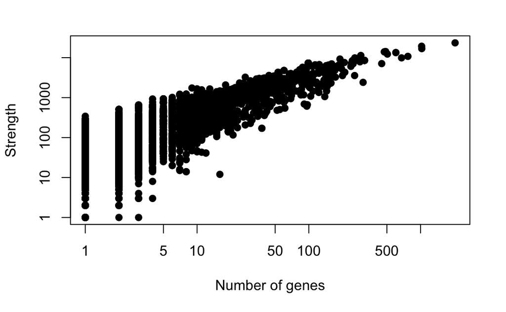

```r
# matching the two tables together
inds_match <- match(names(tb), names(s_diseases))
# plotting one vs the other
plot(as.numeric(tb), s_diseases[inds_match], log='xy', pch=19,
     ylab='Strength', xlab='Number of genes')
```

```r
cor.test(as.numeric(tb), s_diseases[inds_match], method='s')
```

```
Cannot compute exact p-value with ties
```

```
    Spearman's rank correlation rho

data:  as.numeric(tb) and s_diseases[inds_match]
S = 4.2273e+10, p-value < 2.2e-16
alternative hypothesis: true rho is not equal to 0
sample estimates:
      rho
0.7725548
```

# Other centralities

Let us try eigenvector centrality. This tests that nodes are connected to other important nodes. It is similar to the PageRank metric that has been used to rank the importance of google pages.

```r
eig_genes <- eigen_centrality(Gproj$proj1)$vector
eig_diseases <- eigen_centrality(Gproj$proj2)$vector
```

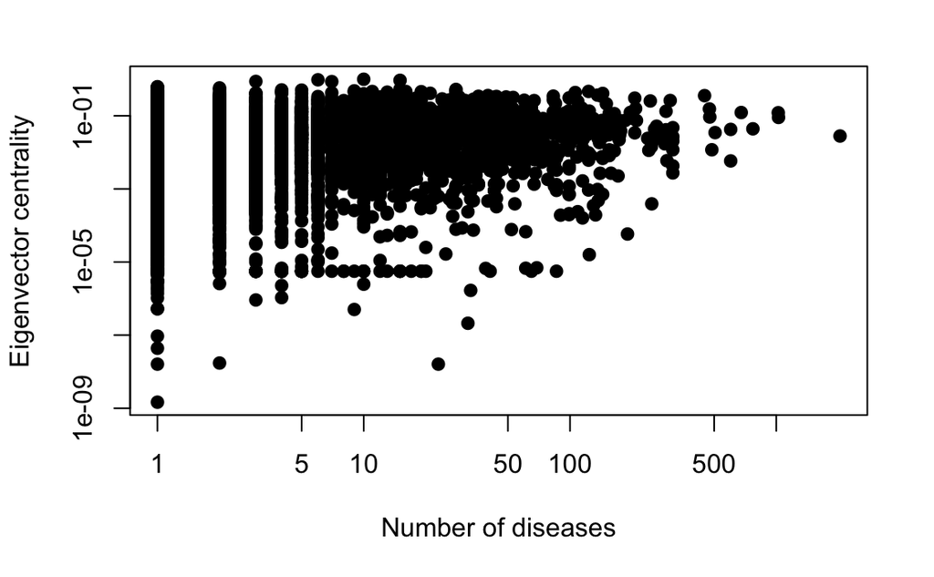

```r
plot(as.numeric(tb), eig_genes[inds_match], log='xy', pch=19,
     ylab='Eigenvector centrality',xlab='Number of diseases')
```

```r
cor.test(as.numeric(tb), eig_genes[inds_match])
```

```
    Pearson's product-moment correlation

data:  as.numeric(tb) and eig_genes[inds_match]
t = 6.5206, df = 9409, p-value = 7.364e-11
alternative hypothesis: true correlation is not equal to 0
95 percent confidence interval:
 0.04693039 0.08715696
sample estimates:
       cor
0.06707093
```

```r
head(sort(eig_genes, decreasing = TRUE), 30)
```

```
     SOD2     PTGS2       IL6      IL1B       TNF       CAT      TP53
1.0000000 0.9669611 0.9355976 0.8730583 0.8632117 0.6243428 0.6084133
     NOS2     MTHFR       LEP      POMC      BDNF       FOS     HMOX1
0.6000075 0.5791721 0.5369964 0.5273373 0.5264188 0.5106659 0.5040236
     KRAS       AGT      EGFR      IGF1      CNR1      PTEN      DRD2
0.5030278 0.4876140 0.4816018 0.4737046 0.4702703 0.4674721 0.4648149
     ACHE    CTNNB1      APOE      BCL2     VEGFA       INS      ESR1
0.4632023 0.4626423 0.4571426 0.4550855 0.4465533 0.4451386 0.4434504
    TGFB1      IFNG
0.4404115 0.4393075
```